# Lab 04 Functions and Visualization

*Elements of Data Science*  
Welcome to lab 4! This week, we will focus on functions and visualization.  
Functions are described in [Chapter 8](https://inferentialthinking.com/chapters/08/Functions_and_Tables.html) of the Inferential Thinking text.  
Visualizations is covered in [Chapter 7](https://inferentialthinking.com/chapters/07/Visualization.html). First, set up the tests and imports by running the cell below.

```python
# Enter your name as a string
name = 'Hannah'
name
```

```
'Hannah'
```

```python
import numpy as np
from datascience import *
%matplotlib inline
import matplotlib.pyplot as plt
plt.style.use('fivethirtyeight')
# Fix for datascience plots
import collections as collections
import collections.abc as abc
collections.Iterable = abc.Iterable
# These lines load the tests.
from gofer.ok import check
```

### Let's explore the most recent COVID data from the New York Times

This data is updated and stored at GitHub: https://github.com/nytimes/covid-19-data  
US rolling average: https://raw.githubusercontent.com/nytimes/covid-19-data/master/rolling-averages/us.csv  
US States rolling average: https://raw.githubusercontent.com/nytimes/covid-19-data/master/rolling-averages/us-states.csv

```python
COVID_data = 'https://raw.githubusercontent.com/nytimes/covid-19-data/master/rolling-averages/us.csv'
COVID=Table.read_table(COVID_data)
COVID=COVID.set_format(0, DateFormatter(format='%Y-%m-%d',))
```

If the above read does not work we can use the data handling packages *pandas* as first discussed in the introduction to Lab 03. It can be run by removing comments, #, in front of the below lines.

```python
import pandas as pd
data_db = pd.read_csv(COVID_data)
COVID = Table.from_df(data_db)
COVID=COVID.set_format(0, DateFormatter(format='%Y-%m-%d',))
```

```python
COVID.sort("date",descending=False) # Display most recent first
```

| date | geoid | cases | cases_avg | cases_avg_per_100k | deaths | deaths_avg | deaths_avg_per_100k |
| --- | --- | --- | --- | --- | --- | --- | --- |
| 2020-01-21 | USA | 1 | 0.14 | 0 | 0 | 0 | 0 |
| 2020-01-22 | USA | 0 | 0.14 | 0 | 0 | 0 | 0 |
| 2020-01-23 | USA | 0 | 0.14 | 0 | 0 | 0 | 0 |
| 2020-01-24 | USA | 1 | 0.29 | 0 | 0 | 0 | 0 |
| 2020-01-25 | USA | 1 | 0.43 | 0 | 0 | 0 | 0 |
| 2020-01-26 | USA | 2 | 0.71 | 0 | 0 | 0 | 0 |
| 2020-01-27 | USA | 0 | 0.71 | 0 | 0 | 0 | 0 |
| 2020-01-28 | USA | 0 | 0.71 | 0 | 0 | 0 | 0 |
| 2020-01-29 | USA | 0 | 0.71 | 0 | 0 | 0 | 0 |
| 2020-01-30 | USA | 1 | 0.86 | 0 | 0 | 0 | 0 |

... (1118 rows omitted)

### Use where to select data from November - December 2021

Here are the possible arguments for the *where* Table method:

| Predicate | Example | Result |
| --- | --- | --- |
| `are.equal_to` | `are.equal_to(50)` | Find rows with values equal to 50 |
| `are.not_equal_to` | `are.not_equal_to(50)` | Find rows with values not equal to 50 |
| `are.above` | `are.above(50)` | Find rows with values above (and not equal to) 50 |
| `are.above_or_equal_to` | `are.above_or_equal_to(50)` | Find rows with values above 50 or equal to 50 |
| `are.below` | `are.below(50)` | Find rows with values below 50 |
| `are.between` | `are.between(2, 10)` | Find rows with values above or equal to 2 and below 10 |

```python
COVID.where("deaths",are.between(0,1))
```

| date | geoid | cases | cases_avg | cases_avg_per_100k | deaths | deaths_avg | deaths_avg_per_100k |
| --- | --- | --- | --- | --- | --- | --- | --- |
| 2020-01-21 | USA | 1 | 0.14 | 0 | 0 | 0 | 0 |
| 2020-01-22 | USA | 0 | 0.14 | 0 | 0 | 0 | 0 |
| 2020-01-23 | USA | 0 | 0.14 | 0 | 0 | 0 | 0 |
| 2020-01-24 | USA | 1 | 0.29 | 0 | 0 | 0 | 0 |
| 2020-01-25 | USA | 1 | 0.43 | 0 | 0 | 0 | 0 |
| 2020-01-26 | USA | 2 | 0.71 | 0 | 0 | 0 | 0 |
| 2020-01-27 | USA | 0 | 0.71 | 0 | 0 | 0 | 0 |
| 2020-01-28 | USA | 0 | 0.71 | 0 | 0 | 0 | 0 |
| 2020-01-29 | USA | 0 | 0.71 | 0 | 0 | 0 | 0 |
| 2020-01-30 | USA | 1 | 0.86 | 0 | 0 | 0 | 0 |

... (39 rows omitted)

Dates produce an error as you will see in the next cell, below we will see the steps needed to work with dates

```python
# Dates produce an error, below we will see the steps needed to work with dates
import time
from time import strptime
time1a = strptime('2021-11-01', '%Y-%m-%d')
time1= time.mktime(time1a)
time2a= strptime('2021-12-01', '%Y-%m-%d')
time2= time.mktime(time2a)
COVID.where(0,are.between(time1,time2))
```

| date | geoid | cases | cases_avg | cases_avg_per_100k | deaths | deaths_avg | deaths_avg_per_100k |
| --- | --- | --- | --- | --- | --- | --- | --- |
| 2021-11-01 | USA | 124570 | 73390.2 | 22.12 | 1151 | 1347.29 | 0.41 |
| 2021-11-02 | USA | 76943 | 71604.6 | 21.58 | 1516 | 1337.15 | 0.4 |
| 2021-11-03 | USA | 84844 | 71166.6 | 21.45 | 1880 | 1328.74 | 0.4 |
| 2021-11-04 | USA | 83087 | 70636 | 21.29 | 1123 | 1295.66 | 0.39 |
| 2021-11-05 | USA | 91768 | 71224.9 | 21.47 | 2321 | 1238.27 | 0.37 |
| 2021-11-06 | USA | 31939 | 71185.9 | 21.45 | 402 | 1228.55 | 0.37 |
| 2021-11-07 | USA | 22085 | 71786.1 | 21.63 | 132 | 1221.68 | 0.37 |
| 2021-11-08 | USA | 126461 | 74097.1 | 22.33 | 1221 | 1208.3 | 0.36 |
| 2021-11-09 | USA | 83651 | 75324.4 | 22.7 | 1716 | 1224.58 | 0.37 |
| 2021-11-10 | USA | 98390 | 76860.2 | 23.16 | 1636 | 1213.69 | 0.37 |

... (20 rows omitted)

### Dates and times in Tables

One thing that is more complicated then we would like but is a common need for a data scientist is encoding data and time. Computer operating systems like Windows and Linux use as a reference point or epoch January 1, 1970 and determine the number of seconds since midnight the start of 1970 to do time computations.  
Seconds since January 1, 1970 today is given by time.time() after importing time module:

```python
import time                # Python time functions
from time import strptime
time.time() # Seconds since common epoch
```

```
1677044058.5742025
```

We can also use a string containing the year, month & day using the *strptime* function.

```python
time0 = strptime('2020-01-21', '%Y-%m-%d')
time.mktime(time0)
```

```
1579564800.0
```

We can also use the data type of the numpy array to generate an appropriate conversion from the number of seconds since midnight the start of 1970 to legible dates.

```python
np.array([0, 1579564800], dtype='datetime64[s]') # See above for seconds resulting from string '2020-01-21'
```

```
array(['1970-01-01T00:00:00', '2020-01-21T00:00:00'], dtype='datetime64[s]')
```

Now we can recast example as a datetime64 object

```python
example = np.array([0, 1579564800])
print('Original example: ',example)
example = example.astype('datetime64[s]')
print('example as datetime64 object: ',example)
```

```
Original example:  [         0 1579564800]
example as datetime64 object:  ['1970-01-01T00:00:00' '2020-01-21T00:00:00']
```

### Question 1:

Determine the number of seconds between January 21, 2020 (considered the start of the COVID pandemic in the US) and December 31, 2021 (both at midnight). Remember doing this in Lab02 for seconds over a period of years.  
Use two methods:  
A) Multiplying 60 seconds * 60 minutes * 24 hours * ... this is `difftimeA`  
B) Using strptime and time.mktime() ... this is `difftimeB`

```python
seconds= 60
minutes= 60
hours_in_one_day= 24
days_from_jan_to_dec= (365*2)-20
difftimeA = seconds* minutes*hours_in_one_day*days_from_jan_to_dec # Compute through multiplaction 60 seconds * 60 minutes * 24 hours * ...

time1a = strptime('2020-01-21', '%Y-%m-%d')
time1 = time.mktime(time1a)
time2a = strptime('2021-12-31', '%Y-%m-%d')
time2 = time.mktime(time2a)

difftimeB = time2-time1
print(difftimeB, difftimeA)
```

```
61344000.0 61344000
```

```python
check('tests/q1a.py')
```

All tests passed!

### Question 2:

The date in the COVID table evaluates to a time in seconds since the epoch like evaluated above. Now define a subset of the data to examine trends between November and December of 2021

```python
time1a = strptime('2021-11-01', '%Y-%m-%d') # Seconds since epoch
time1= time.mktime(time1a)
time2a= strptime('2021-12-01', '%Y-%m-%d')  # Seconds since epoch
time2= time.mktime(time2a)
Late2021 = COVID.where(0,are.between(time1,time2))
Late2021
```

| date | geoid | cases | cases_avg | cases_avg_per_100k | deaths | deaths_avg | deaths_avg_per_100k |
| --- | --- | --- | --- | --- | --- | --- | --- |
| 2021-11-01 | USA | 124570 | 73390.2 | 22.12 | 1151 | 1347.29 | 0.41 |
| 2021-11-02 | USA | 76943 | 71604.6 | 21.58 | 1516 | 1337.15 | 0.4 |
| 2021-11-03 | USA | 84844 | 71166.6 | 21.45 | 1880 | 1328.74 | 0.4 |
| 2021-11-04 | USA | 83087 | 70636 | 21.29 | 1123 | 1295.66 | 0.39 |
| 2021-11-05 | USA | 91768 | 71224.9 | 21.47 | 2321 | 1238.27 | 0.37 |
| 2021-11-06 | USA | 31939 | 71185.9 | 21.45 | 402 | 1228.55 | 0.37 |
| 2021-11-07 | USA | 22085 | 71786.1 | 21.63 | 132 | 1221.68 | 0.37 |
| 2021-11-08 | USA | 126461 | 74097.1 | 22.33 | 1221 | 1208.3 | 0.36 |
| 2021-11-09 | USA | 83651 | 75324.4 | 22.7 | 1716 | 1224.58 | 0.37 |
| 2021-11-10 | USA | 98390 | 76860.2 | 23.16 | 1636 | 1213.69 | 0.37 |

... (20 rows omitted)

```python
check('tests/q2a.py')
```

All tests passed!

### Plot

If we attempt to plot using the 'date' column we get the seconds from the epoch (January 1, 1970). This does not work well so we will address this below.

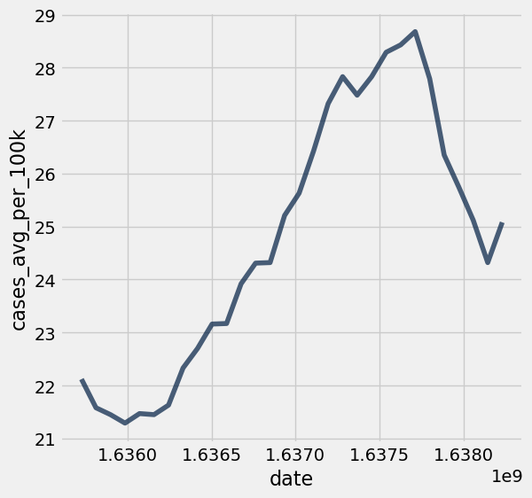

```python
Late2021.plot('date','cases_avg_per_100k')
```

#### Plot with Plotly

[Plotly](https://plotly.com/python/) offers enhanced plots with different syntax. Plotly has become a mainstay in visualizing data. The figure can be saved by clicking on the camera icon in the upper right corner of the figure.

```python
import plotly.express as px

series1 = Late2021.column('cases_avg_per_100k')
date = Late2021.column('date')
fig = px.line(x=date, y=[series1])

fig.show()
```

[interactive chart not shown]

```python
import plotly.express as px

series1 = Late2021.column('cases_avg_per_100k')
date = Late2021.column('date').astype('datetime64[s]') # Using the retyping of the column which is a nump array
fig = px.line(x=date, y=[series1])

fig.show()
```

[interactive chart not shown]

### Histogram

A histogram method is realized by appending .hist('column name')

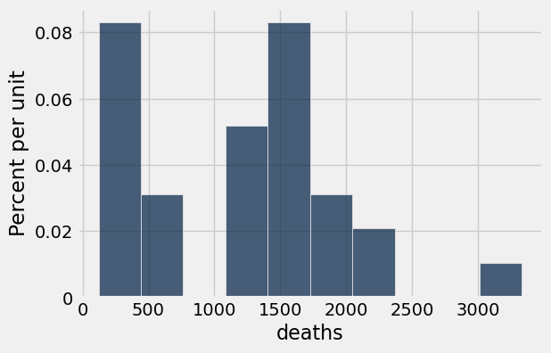

```python
Late2021.hist('deaths')
```

```python
Late2021.stats()
```

| statistic | date | geoid | cases | cases_avg | cases_avg_per_100k | deaths | deaths_avg | deaths_avg_per_100k |
| --- | --- | --- | --- | --- | --- | --- | --- | --- |
| min | 1.63572e+09 | USA | 22085 | 70636 | 21.29 | 121 | 917.71 | 0.28 |
| max | 1.63823e+09 | USA | 216312 | 95172.2 | 28.68 | 3331 | 1347.29 | 0.41 |
| median | 1.63698e+09 |  | 87665 | 81962.6 | 24.7 | 1206 | 1138.37 | 0.345 |
| sum | 4.91093e+10 |  | 2.58669e+06 | 2.46354e+06 | 742.44 | 35440 | 34471 | 10.41 |

### Question 3

Construct a histogram and stats for November - December 2020 and compare this to those from November - December 2021 in a markdown cell below the histogram and statistics.

```python
time1a = strptime('2020-11-01', '%Y-%m-%d')
time1= time.mktime(time1a)
time2a= strptime('2020-12-01', '%Y-%m-%d')
time2= time.mktime(time2a)
Late2020 = COVID.where(0,are.between(time1,time2))
Late2020
```

| date | geoid | cases | cases_avg | cases_avg_per_100k | deaths | deaths_avg | deaths_avg_per_100k |
| --- | --- | --- | --- | --- | --- | --- | --- |
| 2020-11-01 | USA | 74195 | 82648.8 | 24.91 | 428 | 820.8 | 0.25 |
| 2020-11-02 | USA | 94006 | 85497.1 | 25.77 | 540 | 824.6 | 0.25 |
| 2020-11-03 | USA | 92416 | 88094.1 | 26.55 | 1130 | 844.56 | 0.25 |
| 2020-11-04 | USA | 108078 | 91858.4 | 27.68 | 1616 | 869.25 | 0.26 |
| 2020-11-05 | USA | 121349 | 96266.1 | 29.01 | 1108 | 888.73 | 0.27 |
| 2020-11-06 | USA | 132823 | 100960 | 30.43 | 1248 | 930.9 | 0.28 |
| 2020-11-07 | USA | 125931 | 106991 | 32.24 | 1007 | 955.62 | 0.29 |
| 2020-11-08 | USA | 103323 | 111334 | 33.55 | 464 | 949.33 | 0.29 |
| 2020-11-09 | USA | 130444 | 116338 | 35.06 | 745 | 979.68 | 0.3 |
| 2020-11-10 | USA | 139684 | 123090 | 37.1 | 1464 | 1030.93 | 0.31 |

... (20 rows omitted)

```python
check('tests/q3a.py')
```

All tests passed!

| statistic | date | geoid | cases | cases_avg | cases_avg_per_100k | deaths | deaths_avg | deaths_avg_per_100k |
| --- | --- | --- | --- | --- | --- | --- | --- | --- |
| min | 1.60419e+09 | USA | 74195 | 82648.8 | 24.91 | 428 | 820.8 | 0.25 |
| max | 1.60669e+09 | USA | 205839 | 176740 | 53.27 | 2313 | 1686.06 | 0.51 |
| median | 1.60544e+09 |  | 147224 | 152791 | 46.045 | 1201 | 1149.38 | 0.35 |
| sum | 4.81632e+10 |  | 4.40631e+06 | 4.20298e+06 | 1266.68 | 37519 | 36388.3 | 10.98 |

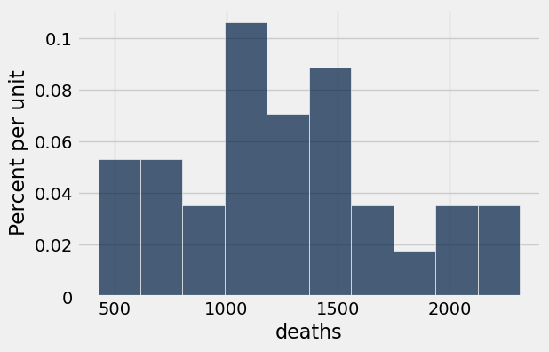

```python
Late2020.hist('deaths')
Late2020.stats()
```

#### Your comparison in this markdown cell (double click to edit)

##### The number of deaths in 2020 were gradually increasing from November to December of 2020. In 2021, about 8% of deaths from the total population were from 0-500 and around 1500. In 2020, about 10% of deaths from the total population ranged around 1000, and 9% of deaths were around 1500.

### Plotting with dates

Dates can also be tricky to get a good x-axis. This is particularly complicated with the time being defined as seconds since the common epoch of January 1, 1970 @12 midnight.

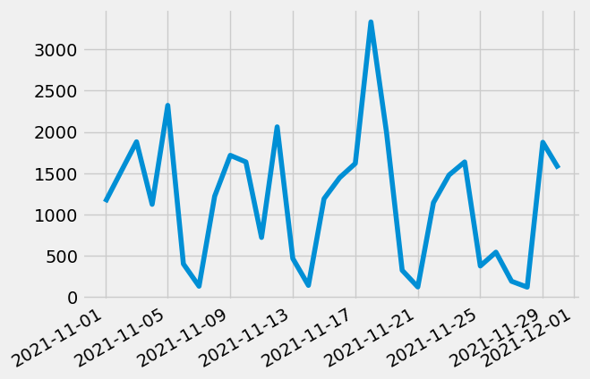

```python
# Input Data to plot
dates = Late2021.column('date')
deaths = Late2021.column('deaths')
# mdates does the trick!
## DATE PLOTTING CODE TEMPLATE TO COPY ##
import matplotlib.dates as mdates
date = Late2021.column('date').astype('datetime64[s]') # Need to convert to a datetime64[s] object
loc = mdates.AutoDateLocator() # Fancy function for dates
fmt = mdates.AutoDateFormatter(loc)
plt.gca().xaxis.set_major_formatter(fmt)
plt.gca().xaxis.set_major_locator(loc)
## END: DATE PLOTTING CODE TEMPLATE TO COPY ##
#
# Now plot
plt.plot(date,deaths)
plt.gcf().autofmt_xdate()
```

### Question 4

Now use the same plotting template (copy from above) and modify to plot your Late2020 data. In the markdown cell below, describe the differences in the line graphs between 2020 and 2021.

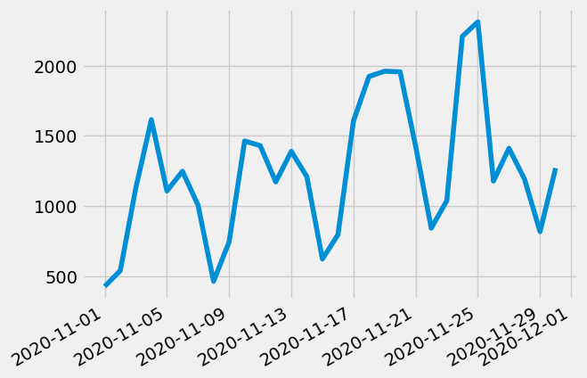

```python
# Plot of November - December 2020 COVID data
dates = Late2020.column('date')
deaths = Late2020.column('deaths')
import matplotlib.dates as mdates
date = Late2020.column('date').astype('datetime64[s]') # Need to convert to a datetime64[s] object
loc = mdates.AutoDateLocator() # Fancy function for dates
fmt = mdates.AutoDateFormatter(loc)
plt.gca().xaxis.set_major_formatter(fmt)
plt.gca().xaxis.set_major_locator(loc)
# Now plot
plt.plot(date,deaths)
plt.gcf().autofmt_xdate()
```

#### Your comparison in this markdown cell (double click to edit)

##### The difference between Line Graph in 2021 versus the Line Graph in 2020 shows that in Line Graph 2020, the number of deaths are rising per day. Additionally, the highest peak for Line graph 202 was in 11-25-2020, where the number of deaths were above 2000. For 2021, the highest peak was around 11-17-2021, where the number of deaths were above 3000.

```python
check('tests/q4a.py')
```

All tests passed!

## 2. Defining functions

Let's write a very simple function that converts a proportion to a percentage by multiplying it by 100. For example, the value of `to_percentage(.5)` should be the number 50. (No percent sign.)

A function definition has a few parts.

##### `def`

It always starts with `def` (short for **def**ine):

```
def
```

##### Name

Next comes the name of the function. Let's call our function `to_percentage`.

```
def to_percentage
```

##### Signature

Next comes something called the *signature* of the function. This tells Python how many arguments your function should have, and what names you'll use to refer to those arguments in the function's code. `to_percentage` should take one argument, and we'll call that argument `proportion` since it should be a proportion. ''' def to_percentage(proportion) '''

We put a colon after the signature to tell Python it's over.

```
def to_percentage(proportion):
```

##### Documentation

Functions can do complicated things, so you should write an explanation of what your function does. For small functions, this is less important, but it's a good habit to learn from the start. Conventionally, Python functions are documented by writing a triple-quoted string:

```
def to_percentage(proportion):
    """Converts a proportion to a percentage."""
```

##### Body

Now we start writing code that runs when the function is called. This is called the *body* of the function. We can write anything we could write anywhere else. First let's give a name to the number we multiply a proportion by to get a percentage.

```
def to_percentage(proportion):
    """Converts a proportion to a percentage."""
    factor = 100
```

##### `return`

The special instruction `return` in a function's body tells Python to make the value of the function call equal to whatever comes right after `return`. We want the value of `to_percentage(.5)` to be the proportion .5 times the factor 100, so we write:

```
def to_percentage(proportion):
    """Converts a proportion to a percentage."""
    factor = 100
    return proportion * factor
```

**Question 5.** Define `to_percentage` in the cell below. Call your function to convert the proportion .2 to a percentage. Name that percentage `twenty_percent`.

```python
def to_percentage(proportion):
    """ Converts the proportion .2 to a percentage """
    factor = 100
    return proportion * factor

twenty_percent = to_percentage(.2)
twenty_percent
```

```
20.0
```

```python
check('tests/q5a.py')
```

All tests passed!

**Question 6.** Now define another function which takes the ratio of two number and then uses the *'to_percentage'* function above to convert it into a percentage. One issue is when the denominator is zero we get a result which is not a number or `nan` in Python. This can be changed to a zero as a place holder with one of the two little tricks shown below that can be incorporated as two lines of your code.

```python
# First approach to deal with dividing by zero
from math import nan
z = nan
print("First: ",z)
# Use this part in your function
if z != z: # if conditional statement
    z = 0
# Up to here
print("Now: ", z)
```

```
First:  nan
Now:  0
```

A second approach which uses Python *try:* and *except:*. The *except:* is executing if the *try:* fails due to an exception such as computing as *nan*.

```python
# Second approach: use this part in your function with z as the ratio
try:
    z = 1/0
except:
    z = 0
print("Now: ", z)
```

```
Now:  0
```

```python
# Now your function...
def ratio(x1,x2):
    """ Computes a ratio of x1 to x2 """
    from math import nan
    z = nan
    if z!= z:
        z= 0
    try:
        z= x1/x2
    except:
        z= 0
    r = to_percentage(z)
    return r
ratio(1,4)
```

```
25.0
```

```python
check('tests/q6a.py')
```

All tests passed!

### COVID cases leading to bad outcomes

Now we will apply the function to our COVID data. Here we will need to use the *with_columns* method of a Table object to add the result of applying the ratio function with two columns as arguments. These columns will be *deaths* and *cases*. The percentage return by the function will create a new column.  
See Inferential Thinking 8.1.1for inspiration:  
https://inferentialthinking.com/chapters/08/1/Applying_a_Function_to_a_Column.html

**Question 7.** Now apply your function to create a new column, *deathrate*. Examine the histogram for deathrate. Now plot the trend for *deathrate* for the entire timeperiod of the dataset. Remember the special codes from above to define the x ('date') and y ('deathrate') data to plot. Discuss the results in the markdown cell below.

```python
from math import nan
z = nan
def ratio(x1,x2):
    """ Computes the ratio of x1 to x2 """
    from math import nan
    z = nan
    if z!= z:
        z= 0
    try:
        z= x1/x2
    except:
        z= 0
    r = to_percentage(z)
    return r
ratio('deaths','cases')

def to_percentage(proportion):
    """ Converts the proportion to a percentage """
    factor = 100
    return proportion * factor
to_percentage('deathrate')

COVID = COVID.with_columns('deathrate',COVID.apply(ratio,'deaths','cases'))
COVID = COVID.where('deathrate', are.above(0))
COVID = COVID.where('deathrate',are.below(1)).sort('deathrate')
# Check that there are no nan...
COVID
```

| date | geoid | cases | cases_avg | cases_avg_per_100k | deaths | deaths_avg | deaths_avg_per_100k | deathrate |
| --- | --- | --- | --- | --- | --- | --- | --- | --- |
| 2022-10-23 | USA | 6975 | 38943.9 | 11.74 | 1 | 360.76 | 0.11 | 0.0143369 |
| 2022-09-04 | USA | 5823 | 87231.6 | 26.29 | 1 | 492.47 | 0.15 | 0.0171733 |
| 2023-01-15 | USA | 3735 | 61000.8 | 18.38 | 1 | 563.88 | 0.17 | 0.0267738 |
| 2022-06-26 | USA | 18238 | 102766 | 30.97 | 6 | 347.92 | 0.1 | 0.0328983 |
| 2022-08-28 | USA | 8539 | 88645.1 | 26.72 | 3 | 480.69 | 0.14 | 0.0351329 |
| 2022-07-10 | USA | 22569 | 107425 | 32.38 | 8 | 322.08 | 0.1 | 0.0354469 |
| 2022-12-24 | USA | 4923 | 70511 | 21.25 | 2 | 428.05 | 0.13 | 0.0406256 |
| 2021-12-26 | USA | 189714 | 214795 | 64.73 | 79 | 1341.68 | 0.4 | 0.0416416 |
| 2022-07-03 | USA | 6861 | 112759 | 33.98 | 3 | 386.93 | 0.12 | 0.0437254 |
| 2023-01-08 | USA | 6100 | 65626.1 | 19.78 | 3 | 508.72 | 0.15 | 0.0491803 |

... (458 rows omitted)

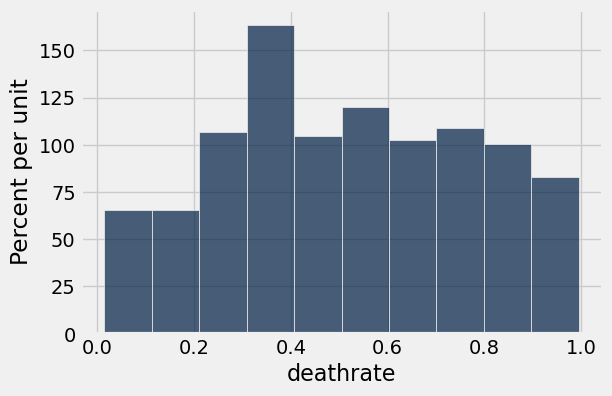

```python
# Histogram
COVID.hist('deathrate')
```

[interactive chart not shown]

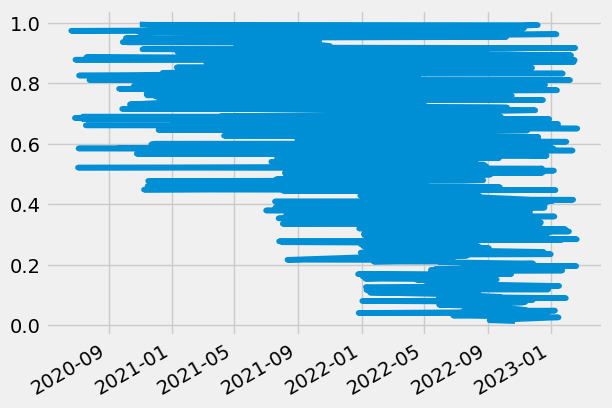

```python
# Plot
# Be sure to re-sort data by date, the plot connect subsequent data points
import plotly.express as px

series1 = COVID.column('deathrate')
date = COVID.column('date').astype('datetime64[s]')
fig = px.line(x=date, y=[series1])
fig.show()

# Input Data to plot
date = COVID.column('date')
deathrate = COVID.column('deathrate')

# mdates does the trick!
## USE DATE PLOTTING CODE TEMPLATE HERE ###

import matplotlib.dates as mdates
date = COVID.column('date').astype('datetime64[s]')
loc = mdates.AutoDateLocator()
fmt = mdates.AutoDateFormatter(loc)
plt.gca().xaxis.set_major_formatter(fmt)
plt.gca().xaxis.set_major_locator(loc)

#Now Plot
plt.plot(date,deathrate)
plt.gcf().autofmt_xdate()
```

#### Your discussion of results from question 7 in this markdown cell (double click to edit)

When plotting the data onto the line graph, the reported number of deaths significantly decreased around 2023 in comparison to 2020.

```python
check('tests/q7a.py')
```

All tests passed!

**Congratulations** , you're done with lab 4! Be sure to run all the tests and verify that they all pass (the next cell has a shortcut for that), Save and Checkpoint from the File menu Run the last two cells for partial grading. Comments and markdown will be graded separately.

```python
# For your convenience, you can run this cell to run all the tests at once!
import glob
from gofer.ok import check
correct = 0
for x in range(1, 8):
    print('Testing question {}: '.format(str(x)))
    g = check('tests/q{}a.py'.format(str(x)))
    if g.grade == 1.0:
        print("Passed")
        correct += 1
    else:
        print('Failed')
        display(g)

print('Grade:  {}'.format(str(correct/7)))
```

```
Testing question 1:
Passed
Testing question 2:
Passed
Testing question 3:
Passed
Testing question 4:
Passed
Testing question 5:
Passed
Testing question 6:
Passed
Testing question 7:
Passed
Grade:  1.0
```

```python
print(name," Great work!")
```

```
Hannah  Great work!
```